# Breast Cancer Wisconsin

```r
#Showing structure of the dataset
str(data)
```

```
## 'data.frame':    569 obs. of  33 variables:
##  $ id                     : int  842302 842517 84300903 84348301 84358402 843786 844359 84458202 844981 84501001 ...
##  $ diagnosis              : chr  "M" "M" "M" "M" ...
##  $ radius_mean            : num  18 20.6 19.7 11.4 20.3 ...
##  $ texture_mean           : num  10.4 17.8 21.2 20.4 14.3 ...
##  $ perimeter_mean         : num  122.8 132.9 130 77.6 135.1 ...
##  $ area_mean              : num  1001 1326 1203 386 1297 ...
##  $ smoothness_mean        : num  0.1184 0.0847 0.1096 0.1425 0.1003 ...
##  $ compactness_mean       : num  0.2776 0.0786 0.1599 0.2839 0.1328 ...
##  $ concavity_mean         : num  0.3001 0.0869 0.1974 0.2414 0.198 ...
##  $ concave.points_mean    : num  0.1471 0.0702 0.1279 0.1052 0.1043 ...
##  $ symmetry_mean          : num  0.242 0.181 0.207 0.26 0.181 ...
##  $ fractal_dimension_mean : num  0.0787 0.0567 0.06 0.0974 0.0588 ...
##  $ radius_se              : num  1.095 0.543 0.746 0.496 0.757 ...
##  $ texture_se             : num  0.905 0.734 0.787 1.156 0.781 ...
```

[output cut: 19 more lines]

```r
#Checking for missing values
colSums(is.na(data))
```

```
##                      id               diagnosis             radius_mean
##                       0                       0                       0
##            texture_mean          perimeter_mean               area_mean
##                       0                       0                       0
##         smoothness_mean        compactness_mean          concavity_mean
##                       0                       0                       0
##     concave.points_mean           symmetry_mean  fractal_dimension_mean
##                       0                       0                       0
##               radius_se              texture_se            perimeter_se
##                       0                       0                       0
##                 area_se           smoothness_se          compactness_se
##                       0                       0                       0
##            concavity_se       concave.points_se             symmetry_se
##                       0                       0                       0
##    fractal_dimension_se            radius_worst           texture_worst
##                       0                       0                       0
##         perimeter_worst              area_worst        smoothness_worst
##                       0                       0                       0
##       compactness_worst         concavity_worst    concave.points_worst
##                       0                       0                       0
##          symmetry_worst fractal_dimension_worst                       X
##                       0                       0                     569
```

```r
#569 total missing values were found in X variable
```

```r
#Treating Missing Values

#Sub-setting out the X variable and saving in a new dataframe
data_clean <- data[,1:32]

#Checking if new data has any missing values
colSums(is.na(data_clean))
```

```
##                      id               diagnosis             radius_mean
##                       0                       0                       0
##            texture_mean          perimeter_mean               area_mean
##                       0                       0                       0
##         smoothness_mean        compactness_mean          concavity_mean
##                       0                       0                       0
##     concave.points_mean           symmetry_mean  fractal_dimension_mean
##                       0                       0                       0
##               radius_se              texture_se            perimeter_se
##                       0                       0                       0
##                 area_se           smoothness_se          compactness_se
##                       0                       0                       0
##            concavity_se       concave.points_se             symmetry_se
##                       0                       0                       0
##    fractal_dimension_se            radius_worst           texture_worst
##                       0                       0                       0
##         perimeter_worst              area_worst        smoothness_worst
##                       0                       0                       0
##       compactness_worst         concavity_worst    concave.points_worst
##                       0                       0                       0
##          symmetry_worst fractal_dimension_worst
##                       0                       0
```

```r
#no missing values found
```

```r
#Removing the ID column
wbcd <- data_clean[,2:32]

#converting the diagnosis variable into a factor
wbcd$diagnosis <- factor(ifelse(wbcd$diagnosis=='B',"Bening","Malignant"))

#now converting diagnosis as a double - 1 if Malignant and 0 if Benign
wbcd_n <- wbcd %>%
  mutate_at(vars(diagnosis), as.double) %>%
  mutate(diagnosis = diagnosis - 1)


#checking the structure of the new dataframe
str(wbcd_n)
```

```
## 'data.frame':    569 obs. of  31 variables:
##  $ diagnosis              : num  1 1 1 1 1 1 1 1 1 1 ...
##  $ radius_mean            : num  18 20.6 19.7 11.4 20.3 ...
##  $ texture_mean           : num  10.4 17.8 21.2 20.4 14.3 ...
##  $ perimeter_mean         : num  122.8 132.9 130 77.6 135.1 ...
##  $ area_mean              : num  1001 1326 1203 386 1297 ...
##  $ smoothness_mean        : num  0.1184 0.0847 0.1096 0.1425 0.1003 ...
##  $ compactness_mean       : num  0.2776 0.0786 0.1599 0.2839 0.1328 ...
##  $ concavity_mean         : num  0.3001 0.0869 0.1974 0.2414 0.198 ...
##  $ concave.points_mean    : num  0.1471 0.0702 0.1279 0.1052 0.1043 ...
##  $ symmetry_mean          : num  0.242 0.181 0.207 0.26 0.181 ...
##  $ fractal_dimension_mean : num  0.0787 0.0567 0.06 0.0974 0.0588 ...
##  $ radius_se              : num  1.095 0.543 0.746 0.496 0.757 ...
##  $ texture_se             : num  0.905 0.734 0.787 1.156 0.781 ...
##  $ perimeter_se           : num  8.59 3.4 4.58 3.44 5.44 ...
```

[output cut: 17 more lines]

```r
#all numeric variables
```

Now we know the data is clean and we can run some Visualization and Analysis

## Data Visualization

Distribution of the diagnosis variable -

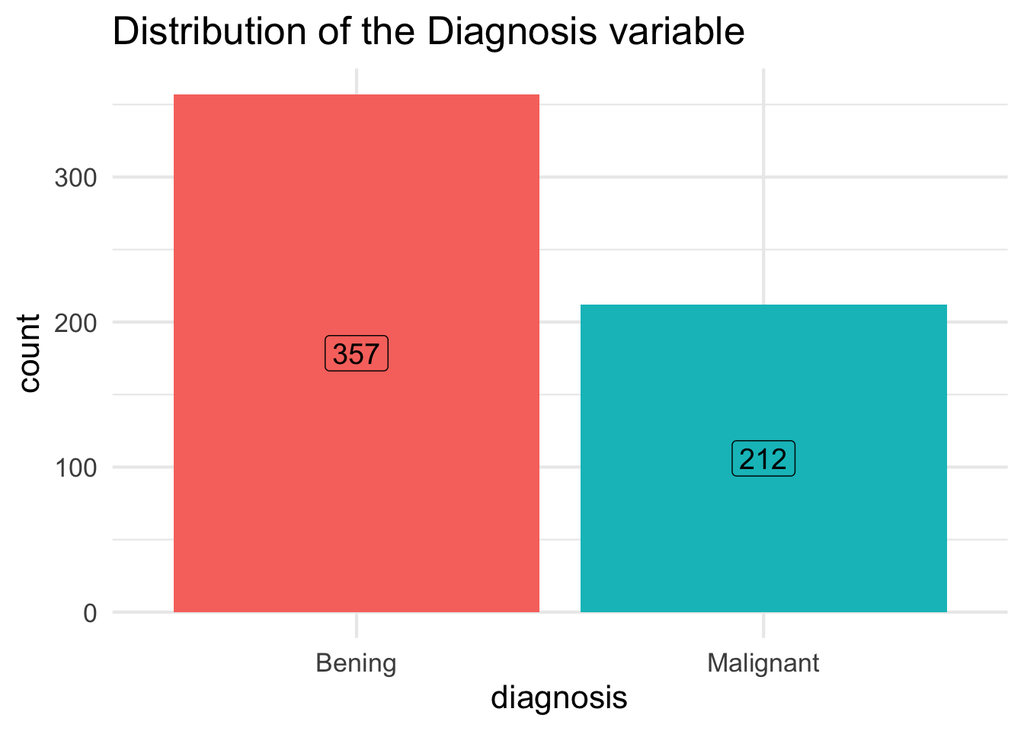

```r
#visualizing the diagnosis variable
p1 <- ggplot(wbcd, aes(x = diagnosis, fill = diagnosis)) +
  geom_bar(stat = "count", position = "stack", show.legend = FALSE) +
  theme_minimal(base_size = 16) +
  geom_label(stat = "count", aes(label = after_stat(count)), position = position_stack(vjust = 0.5),
             size = 5, show.legend = FALSE)

p1 +
  ggtitle("Distribution of the Diagnosis variable")
```

After looking at the distribution we notice that the diagnosis variable is biased.

## Correlation Analysis

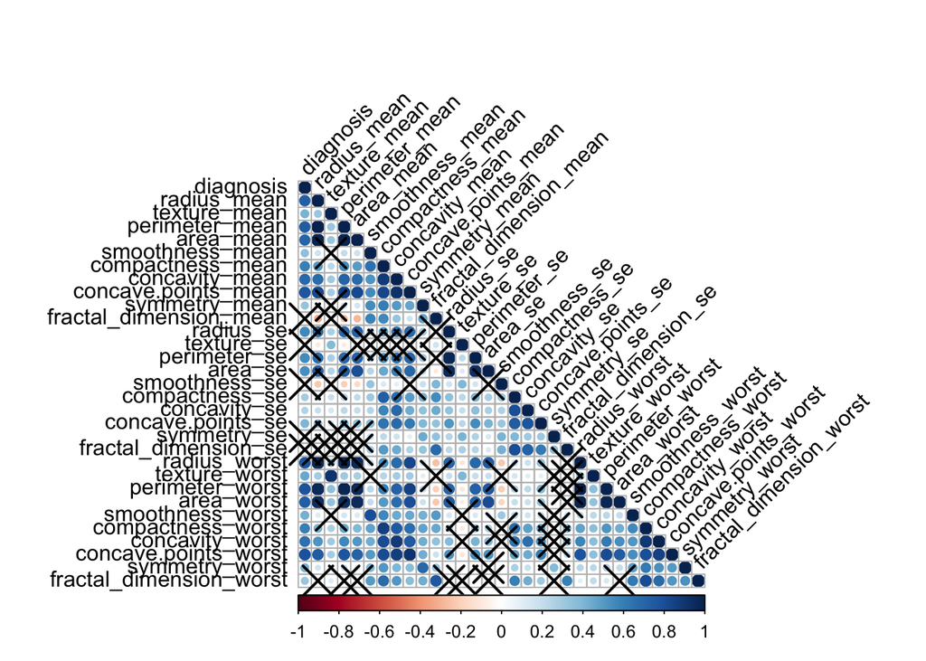

```r
#checking the correlation matrix
cor(wbcd_n) %>%
  corrplot(method = "circle", type = "lower", tl.col = "black", tl.srt = 45, p.mat = cor.mtest(wbcd_n)$p, sig.level = 0.05)
```

We notice that many of the independent variables are very strongly correlated, which suggests that there is multicollinearity.

## Descriptive Analysis

```r
#showing descriptive analysis for the numeric dataframe
describe(wbcd_n)
```

|  | vars | n | mean | sd | median | trimmed | mad | min | max | range | skew | kurtosis | se |
| --- | --- | --- | --- | --- | --- | --- | --- | --- | --- | --- | --- | --- | --- |
| diagnosis | 1 | 569 | 3.725835e-01 | 4.839180e-01 | 0.000e+00 | 3.413567e-01 | 0.000000e+00 | 0.000e+00 | 1.000e+00 | 1.00000e+00 | 0.5256783 | -1.7266876 | 2.028690e-02 |
| radius_mean | 2 | 569 | 1.412729e+01 | 3.524049e+00 | 1.337e+01 | 1.381991e+01 | 2.816940e+00 | 6.981e+00 | 2.811e+01 | 2.11290e+01 | 0.9374168 | 0.8141418 | 1.477358e-01 |
| texture_mean | 3 | 569 | 1.928965e+01 | 4.301036e+00 | 1.884e+01 | 1.903779e+01 | 4.166106e+00 | 9.710e+00 | 3.928e+01 | 2.95700e+01 | 0.6470241 | 0.7280071 | 1.803088e-01 |
| perimeter_mean | 4 | 569 | 9.196903e+01 | 2.429898e+01 | 8.624e+01 | 8.974046e+01 | 1.884385e+01 | 4.379e+01 | 1.885e+02 | 1.44710e+02 | 0.9854334 | 0.9392821 | 1.018666e+00 |
| area_mean | 5 | 569 | 6.548891e+02 | 3.519141e+02 | 5.511e+02 | 6.061278e+02 | 2.272826e+02 | 1.435e+02 | 2.501e+03 | 2.35750e+03 | 1.6370654 | 3.5865488 | 1.475301e+01 |
| smoothness_mean | 6 | 569 | 9.636028e-02 | 1.406413e-02 | 9.587e-02 | 9.587740e-02 | 1.408470e-02 | 5.263e-02 | 1.634e-01 | 1.10770e-01 | 0.4539207 | 0.8244671 | 5.895989e-04 |
| compactness_mean | 7 | 569 | 1.043410e-01 | 5.281276e-02 | 9.263e-02 | 9.808295e-02 | 4.837724e-02 | 1.938e-02 | 3.454e-01 | 3.26020e-01 | 1.1838556 | 1.6088967 | 2.214026e-03 |
| concavity_mean | 8 | 569 | 8.879932e-02 | 7.971981e-02 | 6.154e-02 | 7.725070e-02 | 5.998600e-02 | 0.000e+00 | 4.268e-01 | 4.26800e-01 | 1.3938008 | 1.9531357 | 3.342028e-03 |
| concave.points_mean | 9 | 569 | 4.891915e-02 | 3.880284e-02 | 3.350e-02 | 4.400013e-02 | 2.985956e-02 | 0.000e+00 | 2.012e-01 | 2.01200e-01 | 1.1650124 | 1.0324689 | 1.626700e-03 |
| symmetry_mean | 10 | 569 | 1.811619e-01 | 2.741428e-02 | 1.792e-01 | 1.795230e-01 | 2.535246e-02 | 1.060e-01 | 3.040e-01 | 1.98000e-01 | 0.7217877 | 1.2511350 | 1.149266e-03 |

[output cut: 21 more lines]

We see that radius_se (3.07), perimeter_se (3.43), area_se(5.42), concavity_se (5.08) and fractal_dimension_se (3.90) are some of the highly skewed variables. We see observe that texture_worse(0.50) and diagnosis(0.53) are approximately symmetric. The highest mean values were found for area_mean (654.89), area_worst (880.58) and perimeter_worst (107.26). The lowest mean values was for fractal_dimension_se (0.00).

## Statstical Analysis

Before running Factor Analysis, we need to check for the factoribility of the dataset by running the below tests

```r
#Testing KMO Sampling Adequacy
KMO(wbcd_n)
```

```
## Kaiser-Meyer-Olkin factor adequacy
## Call: KMO(r = wbcd_n)
## Overall MSA =  0.84
## MSA for each item =
##               diagnosis             radius_mean            texture_mean
##                    0.99                    0.84                    0.66
##          perimeter_mean               area_mean         smoothness_mean
##                    0.86                    0.87                    0.82
##        compactness_mean          concavity_mean     concave.points_mean
##                    0.88                    0.90                    0.91
##           symmetry_mean  fractal_dimension_mean               radius_se
##                    0.83                    0.83                    0.84
##              texture_se            perimeter_se                 area_se
##                    0.49                    0.85                    0.86
##           smoothness_se          compactness_se            concavity_se
##                    0.65                    0.87                    0.83
##       concave.points_se             symmetry_se    fractal_dimension_se
##                    0.84                    0.58                    0.81
##            radius_worst           texture_worst         perimeter_worst
##                    0.83                    0.62                    0.89
##              area_worst        smoothness_worst       compactness_worst
##                    0.83                    0.76                    0.86
##         concavity_worst    concave.points_worst          symmetry_worst
##                    0.91                    0.90                    0.70
## fractal_dimension_worst
##                    0.82
```

```r
#Overall MSA = 0.84
```

```r
#Testing Bartlett's Test of Sphericity
bart_spher(wbcd_n)
```

```
##  Bartlett's Test of Sphericity
##
## Call: bart_spher(x = wbcd_n)
##
##      X2 = 40167.506
##      df = 465
## p-value < 2.22e-16
```

```r
#p-value < 2.22e-16
```

```r
#Checking the Cronbach's Alpha
cronbach.alpha(wbcd_n)
```

```
##
## Cronbach's alpha for the 'wbcd_n' data-set
##
## Items: 31
## Sample units: 569
## alpha: 0.585
```

```r
#raw_alpha = 0.58
```

The KMO Sampling Test gave us a MSA value of 0.84, which confirms that the sample used is sufficient. We see the the Bartlett’s Test of Sphericity has a p-value of less than 0.05 demonstrating that the correlation matrix is not an identity matrix, therefore providing justification to use Factor Analysis. Usual we accept a sample only when the Cronbach’s alpha is greater than 0.6 but I am making an exception with my dataset.

## Parallel Analysis

Parallel Analysis can helps us determine how many factors we need to use in factor analysis. Parallel Analysis can be used as a guess and not a final answer, it gives us something to get started.

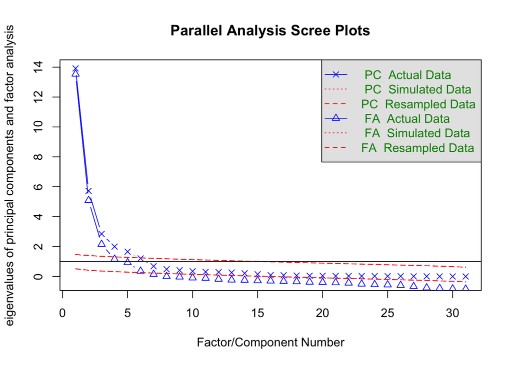

```
## Parallel analysis suggests that the number of factors =  6  and the number of components =  5
```

```r
#running parallel analysis
comp <- fa.parallel(wbcd_n)
```

```r
comp
```

```
## Call: fa.parallel(x = wbcd_n)
## Parallel analysis suggests that the number of factors =  6  and the number of components =  5
##
##  Eigen Values of
##   Original factors Resampled data Simulated data Original components
## 1            13.54           0.52           0.51               13.92
## 2             5.08           0.42           0.41                5.73
## 3             2.15           0.36           0.35                2.85
## 4             1.16           0.33           0.32                2.00
## 5             0.93           0.29           0.29                1.66
## 6             0.36           0.26           0.26                1.21
##   Resampled components Simulated components
## 1                 1.47                 1.46
## 2                 1.41                 1.40
## 3                 1.35                 1.34
## 4                 1.31                 1.31
## 5                 1.28                 1.27
## 6                 1.25                 1.24
```

Parallel Analysis suggests that we should be using 6 factors but let’s take a look at eigenvalues which are greater than 1

```r
#checking for eigenvalues which are greater than 1
sum(comp$fa.values>1)
```

```
## [1] 4
```

Now since we know that there are four factors which have eigenvalues that are greater than 1, we will start by using 4 factors

## Common Factor Analysis

```r
#Conducting factor analysis
fit = factanal(wbcd_n[,-1], 4, rotation = "varimax", lower = 0.1)
print(fit$loadings, cutoff=0.5, sort=T)
```

```
##
## Loadings:
##                         Factor1 Factor2 Factor3 Factor4
## radius_mean              0.943
## perimeter_mean           0.941
## area_mean                0.962
## concave.points_mean      0.782   0.548
## radius_se                0.828
## perimeter_se             0.814           0.503
## area_se                  0.874
## radius_worst             0.939
## perimeter_worst          0.932
## area_worst               0.945
## smoothness_mean                  0.596
## compactness_mean                 0.828
## concavity_mean           0.631   0.690
## symmetry_mean                    0.545
## fractal_dimension_mean           0.705
## compactness_se                   0.686
## concavity_se                     0.582
## fractal_dimension_se             0.546   0.545
## smoothness_worst                 0.641
## compactness_worst                0.870
## concavity_worst                  0.812
## concave.points_worst     0.660   0.671
## symmetry_worst                   0.596
## fractal_dimension_worst          0.870
## texture_se                               0.528
## smoothness_se                            0.598
## symmetry_se                              0.569
## texture_mean                                     0.914
## texture_worst                                    0.918
## concave.points_se
##
##                Factor1 Factor2 Factor3 Factor4
## SS loadings      9.854   7.634   3.018   2.077
## Proportion Var   0.328   0.254   0.101   0.069
## Cumulative Var   0.328   0.583   0.684   0.753
```

```r
#Displaying the summary
summary(fit)
```

```
##              Length Class    Mode
## converged      1    -none-   logical
## loadings     120    loadings numeric
## uniquenesses  30    -none-   numeric
## correlation  900    -none-   numeric
## criteria       3    -none-   numeric
## factors        1    -none-   numeric
## dof            1    -none-   numeric
## method         1    -none-   character
## rotmat        16    -none-   numeric
## STATISTIC      1    -none-   numeric
## PVAL           1    -none-   numeric
## n.obs          1    -none-   numeric
## call           5    -none-   call
```

Interpretation -

Names of the components -

Factor 1 - size, as it speaks about how large a nuclei is Factor 2 - distortion, as it describes the distorted cells outline Factor 3 - variety, as it tells us the variety of cell nuclei Factor 4 - texture, as it talks about the texture of the nuclei

## Conclusion

We arrive at a conclusion that there are four main characteristics which are needed to detect breast cancer and among these four characteristics, size is one of the most important characteristics to consider. In actual medical practice, the degree of “nuclear atypia” of cells is used to classify the malignancy of breast cancer. The larger the cell nucleus, the more chromatin is increased and unevenly distributed, and the more distorted the nuclear outline, the more abnormal the cell is considered to be. [3] The above mentioned study confirms are findings.

# References

1.Wolberg,William, Mangasarian,Olvi, Street,Nick, and Street,W.. (1995). Breast Cancer Wisconsin (Diagnostic). UCI Machine Learning Repository. https://doi.org/10.24432/C5DW2B.

2.American Cancer Society (n.d.). Fine Needle Aspiration (FNA) of the Breast. Cancer.org. https://www.cancer.org/cancer/types/breast-cancer/screening-tests-and-early-detection/breast-biopsy/fine-needle-aspiration-biopsy-of-the-breast.html#:~:text=During%20a%20fine%20needle%20aspiration,needle%20biopsy%20is%20often%20preferred).

3.Okudela K. (2014). An association between nuclear morphology and immunohistochemical expression of p53 and p16INK4A in lung cancer cells. Medical molecular morphology, 47(3), 130–136. https://doi.org/10.1007/s00795-013-0052-x